# Preproducible Research Project 1, Coursera

Y.C. Chris Lau

2018-08-21

# Reproducible Research Project 1

## Loading and preprocessing the data

##### 1. Load the data (i.e. read.csv())

```r
fileurl <- "https://d396qusza40orc.cloudfront.net/repdata%2Fdata%2Factivity.zip"
zipfile <- "repdata%2Fdata%2Factivity.zip"
filename <- "repdata%2Fdata%2Factivity"

 if(!file.exists(zipfile)){
    donwload.file(fileurl, destfile = zipfile, method = "curl")
}
```

```
## Error in donwload.file(fileurl, destfile = zipfile, method = "curl"): could not find function "donwload.file"
```

```r
if(!file.exists(filename)){
    unzip(zipfile)
}
act.data <- read.csv("activity.csv", header = TRUE, sep = ",")
```

##### 2. Process/transform the data (if necessary) into a format suitable for your analysis

```r
act.data$date <- as.Date(act.data$date, "%Y-%m-%d")

summary(act.data)
```

```
##      steps             date               interval
##  Min.   :  0.00   Min.   :2012-10-01   Min.   :   0.0
##  1st Qu.:  0.00   1st Qu.:2012-10-16   1st Qu.: 588.8
##  Median :  0.00   Median :2012-10-31   Median :1177.5
##  Mean   : 37.38   Mean   :2012-10-31   Mean   :1177.5
##  3rd Qu.: 12.00   3rd Qu.:2012-11-15   3rd Qu.:1766.2
##  Max.   :806.00   Max.   :2012-11-30   Max.   :2355.0
##  NA's   :2304
```

## What is mean total number of steps taken per day?

##### 1. Calculate the total number of steps taken per day

```r
tot.step.day <- act.data %>%
    group_by(date) %>%
    summarize(tot.day = sum(steps, na.rm = TRUE))
```

##### 2. Make a histogram of the total number of steps taken each day

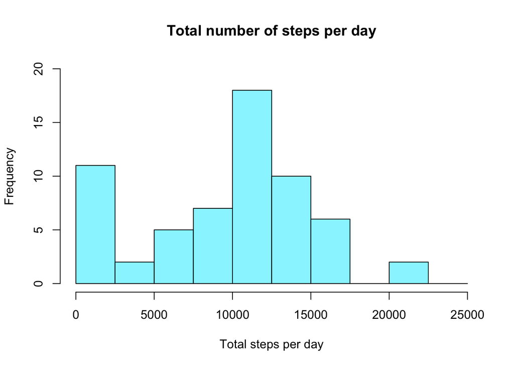

```r
tot.step.day.plot <- with(tot.step.day,
                         hist(tot.day, col = "cadetblue1",
                              breaks = seq(0,25000, by=2500),
                              ylim = c(0,20),
                              main = "Total number of steps per day",
                              xlab = "Total steps per day",
                              ylab = "Frequency"))
```

##### 3. Calculate and report the mean and median of the total number of steps taken per day

```r
tot.step.day.mean <- mean(tot.step.day$tot.day)
tot.step.day.median <- median(tot.step.day$tot.day)

print(tot.step.day.mean)
```

```
## [1] 9354.23
```

```r
print(tot.step.day.median)
```

```
## [1] 10395
```

## What is the average daily activity pattern?

##### 1. Make a time series plot of the 5-minute interval (x-axis) and the average number of steps taken, averaged across all days (y-axis)

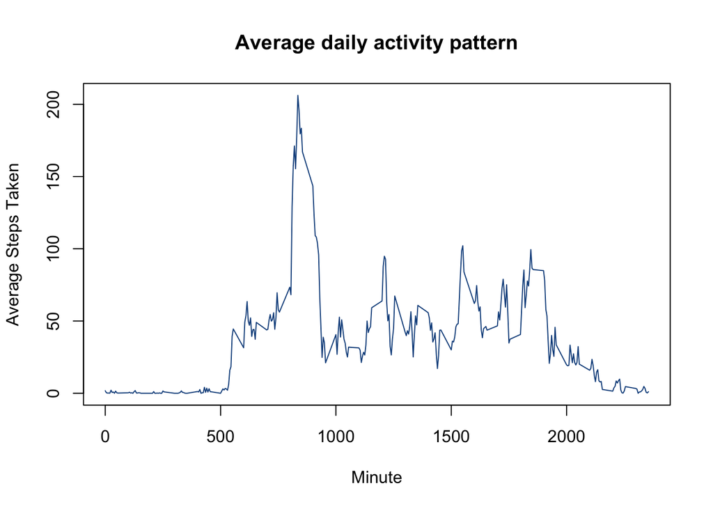

```r
ave.step.int <- act.data %>%
        group_by(interval) %>%
        summarize(ave.step = mean(steps, na.rm = TRUE))

ave.step.int.plot <- with(ave.step.int,
                          plot( x = interval,
                                y = ave.step,
                                type = "l",
                                col = "dodgerblue4",
                                main = "Average daily activity pattern",
                                xlab = "Minute",
                                ylab = "Average Steps Taken"))
```

##### 2. Show the 5-minutes interval containing the maximum number of steps.

```r
max.int <- ave.step.int$ave.step %>%
    which.max() %>%
    ave.step.int[.,"interval"] %>%
    as.numeric()

print(max.int)
```

```
## [1] 835
```

## Imputing missing values

##### 1. Calculate and report the total number of missing values in the dataset.

```r
tot.miss <- act.data$steps %>%
        is.na() %>%
        sum()

print(tot.miss)
```

```
## [1] 2304
```

##### 2. Devise a strategy for filling in all of the missing values in the dataset.

```r
data.fill <- data.frame(act.data)
    for (i in seq_along(data.fill$steps)){
        if(is.na(data.fill[i,"steps"])){
            data.fill[i,"steps"] <- ave.step.int$ave.step[which(data.fill[i,"interval"] == ave.step.int$interval)]
        }
    }
```

##### 3. Create a new dataset that is equal to the original dataset but with the missing data filled in.

```r
tot.step.day.filled <- data.fill %>%
        group_by(date) %>%
        summarize(tot.day = sum(steps, na.rm = TRUE))
```

##### 4. Make a histogram of the total number of steps taken each day and Calculate.

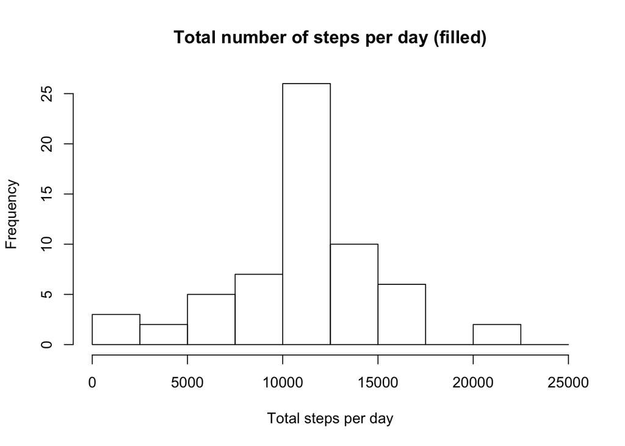

```r
tot.day.filled.plot <- with(tot.step.day.filled,
                            hist(x = tot.day ,
                                 breaks = seq(0,25000, by = 2500),
                                 main = "Total number of steps per day (filled)",
                                 xlab = "Total steps per day",
                                 ylab = "Frequency"))
```

##### 5. Report the mean and median total number of steps taken per day with filled values.

```r
tot.step.day.mean.filled <- mean(tot.step.day.filled$tot.day)
print(tot.step.day.mean.filled)
```

```
## [1] 10766.19
```

```r
tot.step.day.median.filled <- median(tot.step.day.filled$tot.day)
print(tot.step.day.median.filled)
```

```
## [1] 10766.19
```

## Are there differences in activity patterns between weekdays and weekends?

##### 1. Create a new factor variable in the dataset with two levels – “weekday” and “weekend” indicating whether a given date is a weekday or weekend day.

```r
weekdays.list <- with(act.data, sapply(date, function(x){
    if (weekdays(x) == "Saturday"| weekdays(x) == "Sunday")
        { week.type <- "Weekend"} else
        { week.type <- "Weekday"}
    week.type
}))

act.data.week <- cbind(act.data, weekdays.list)

ave.step.int.week <- act.data.week %>%
    group_by(interval,weekdays.list) %>%
    summarize(step.int.week = mean(steps, na.rm = TRUE))
```

##### 2. Make a panel plot containing a time series plot of the 5-minute interval (x-axis) and the average number of steps taken, averaged across all weekday days or weekend days (y-axis)

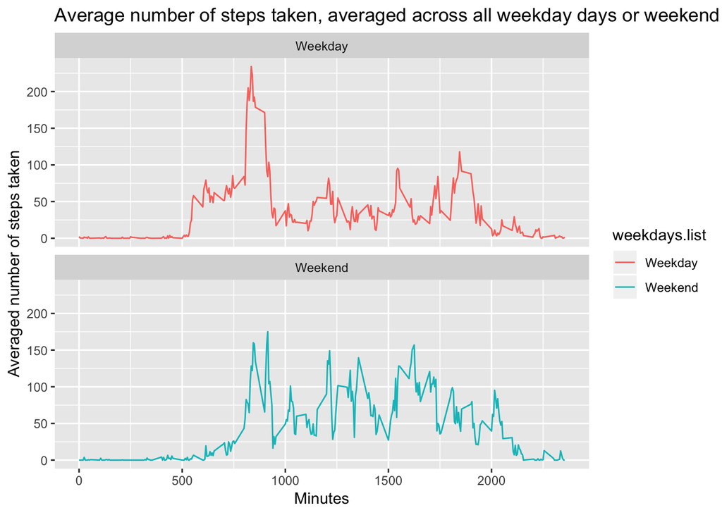

```r
week.plot <- ggplot(ave.step.int.week, aes(x = interval, y = step.int.week, color = weekdays.list)) +
        geom_line() +
        facet_wrap( ~weekdays.list, ncol = 1, nrow = 2) +
        xlab("Minutes") +
        ylab("Averaged number of steps taken") +
        ggtitle("Average number of steps taken, averaged across all weekday days or weekend days")

print(week.plot)
```